# November_updates

November 28, 2023

# 1 Nov 28th

## 1.1 Goal

The overall goal of this analysis is to visualize the distribution of 3mer-GAT corresponding to its closest ChIP peak summit.  
**Step1**: find the closest 3mer-GAT to each ChIP peak summit.  
**Step2**: set closest 3mer-GAT as the new anchor point; draw composite profile of 3mer-GAT distribution upstream/downstream of the anchor point.

## 1.2 Install required packages

Install `bigWig` package

```r
install.packages("devtools")
library(devtools)
devtools::install_github('andrelmartins/bigWig',
              subdir='bigWig')
```

[output not shown]

```r
library(bigWig)

install.packages("latticeExtra")
```

Install `bedtools`

```bash
/bin/bash -c "$(curl -fsSL https://raw.githubusercontent.com/Homebrew/install/HEAD/install.sh)"
brew install bedtools
```

## 1.3 step1: find the closest 3mer-GAT to each ChIP peak summit

In this section, we first use `seqOutBias` to generate all 3mer coordinates file, then we use Bedtools `closestbed` to find overlap/closest GAT to each provided peak summit.

### 1.3.1 Generate the 3mer coordinates file on the reference genome.

**3mer_df**: generating a .txt file where the first column are all 64 3mer, second column are the index, and the third column are the corresponding reversed 3mer’s index (indexrc).

```r
#define function to output the reverse compliment sequence
revcomp <- function(sequence) {
  complement_mapping <- c("A" = "T", "T" = "A", "C" = "G", "G" = "C")
  complemented_sequence <- sapply(strsplit(rev(strsplit(sequence, "")[[1]]), NULL), function(base) complement_mapping[base])
  complemented_sequence <- paste(complemented_sequence, collapse = "")
  return(complemented_sequence)
}

# 64 3mer with index
all.64 = expand.grid(rep(list(c('A','C','G','T')), 3))
all.64.df = data.frame(apply(all.64, 1 , paste, collapse = ""))
all.64.df[,1] = all.64.df[order(all.64.df[,1]),]
all.64.df[,2] = 1:64

# 64 reversed 3mer with indexrc
rev.df = data.frame(as.character(all.64.df[,1]))
rev.df[] = apply(rev.df, 1, revcomp)
rev.df[,2] = 1:64
colnames(rev.df)= c('rc', 'indexrc')


colnames(all.64.df) = c('three_mer', 'index')
all.64.df.rc = merge(all.64.df, rev.df, by.x = 'three_mer', by.y = 'rc')
write.table(all.64.df.rc, file = 'all_64_df.txt', quote=FALSE, row.names =FALSE, col.names = FALSE, sep = '\t')
```

```bash
head all_64_df.txt
```

```
## AAA  1   64
## AAC  2   48
## AAG  3   32
## AAT  4   16
## ACA  5   60
## ACC  6   44
## ACG  7   28
## ACT  8   12
## AGA  9   56
## AGC  10  40
```

```bash
#cd /home/FCAM/ssun/Genome/hg38/
wget https://hgdownload.cse.ucsc.edu/goldenpath/hg38/chromosomes/chr10.fa.gz
gunzip chr10.fa.gz
cat /home/FCAM/ssun/Genome/hg38/chr10.fa | head -4000000 > /home/FCAM/ssun/seqoutbias/chr10_kmer3/refreads4M/chr10_4M.fa
```

**seqOutBias** `seqOutBias seqtable` will generate a seqtable file (.tbl) which is a compressed form that stores the mappability information (if you provide aligned reads info) as well as corresponding parameters (read length, k-mer size, and cut-site offsets).

`seqOutBias dump` can extract info from the seqtable file and output plain txt file in a form of “chrom:start-end”. It will also list the input parameters (read-size, kmer-size, etc.) that were used to build the sequence table file.

```bash
hostname
export PATH=$PATH:/home/FCAM/ssun/packages/://home/FCAM/ssun/scripts
module load genometools/1.5.10
module load ucsc_genome/2012.05.22
module load rust

# use a small hg38 genome subset (2million reads in chr10)
genome=/home/FCAM/ssun/seqoutbias/chr10_kmer3/refreads4M/chr10_4M.fa

seqOutBias seqtable ${genome} --read-size=30 --kmer-size=3 --plus-offset=3 --minus-offset=3 --out=chr10_4M.3.3.3.tbl
seqOutBias dump chr10_4M.3.3.3.tbl > chr10_4M.3.3.3.dump.txt
```

The output “chr10_4M.3.3.3.dump.txt” file is 2GB large, a subset of the top 500 lines from this large file is saved (head500_chr10_4M.3.3.3.dump.txt) and can be visualize here:

```bash
head -15 head500_chr10_4M.3.3.3.dump.txt
```

```
## # kmer-size:    3
## # plus-offset:  3
## # minus-offset: 3
## # read-size:    30
## # strand-specific: false
## >chr10 133797422
## 0    0   0
## 1    0   0
## 2    0   0
## 3    0   0
## 4    0   0
## 5    0   0
## 6    0   0
## 7    0   0
## 8    0   0
```

In this dump.txt file, the first column is chromosome region (of each base position), the second and third columns are index and reversed index. We see many 0s in 2nd and 3rd columns in the above headed file, because these are Ns in the beginning of chromosome genome file. These Ns come from repetitive DNA sequences such as telomeres and centromeres that is hard for sequencer to recognize.

In the next step, we use a python script `dump_to_kmer.py` to generate 128 (64 3mer +64 reversed 3mer) .bed files that contain the 3mer coordinates info (chr-start-end-index-inderc-strand-3mersequence).

```bash
mkdir seqdump_test
mv chr10_4M.3.3.3.dump.txt seqdump_test
mv all_64_df.txt seqdump_test
cd seqdump_test

while read line; do
 mer=$(echo $line | awk -F" " '{print $1}')
 idx=$(echo $line | awk -F" " '{print $2}')
 rcidx=$(echo $line | awk -F" " '{print $3}')
 echo $mer
 echo $idx
 echo $rcidx
 python /home/FCAM/ssun/scripts/dump_to_kmer.py -i chr10_4M.3.3.3.dump.txt -p $idx -m $rcidx -s $mer
done <all_64_df.txt
```

**coherence check**

To test if the output .bed file indeed contains the corresponding 3mer sequence at its genome coordinates, we use `bedtools getfasta` to extract the actual sequence from reference genome based on the provided bed coordinates.

```bash
#bed to fasta (extract the actual sequence from reference genome based on the provided bed coordinates)
module load bedtools
genome=/home/FCAM/ssun/seqoutbias/chr10_kmer3/refreads4M/chr10_4M.fa
plus_file=/labs/Guertin/siyu/Sathyan_GATA3_ChIP_pool1_pool2/overrep_3mer/seqdump_test/chr10_4M.3.3.3plus.36_GAT.bed
minus_file=/labs/Guertin/siyu/Sathyan_GATA3_ChIP_pool1_pool2/overrep_3mer/seqdump_test/chr10_4M.3.3.3minus.14_GAT.bed
bedtools getfasta -fi ${genome} -bed ${plus_file}  -fo chr10_4M.3.3.3plus.36_GAT.fasta
bedtools getfasta -fi ${genome} -bed ${minus_file}  -fo chr10_4M.3.3.3minus.14_GAT.fasta
```

Here I am doing two coherence check:  
First see if `bedtools getfasta` successfully converting .bed to .fa without losing any information. We use `wc -l` to get total number of lines in each files;  
We also want to know if the .bed coordinates represents the expected 3mer sequence, we can use `grep` and `wc -l` to get number of lines contains the expected sequence (GAT or ATC) in the .fa file. If coordinates in .bed are accurate, we should have same number of lines containing GAT or ATC in .fa file as the .bed file.

```bash
x=$(wc -l chr10_4M.3.3.3plus.36_GAT.bed | awk '{print $1}')
y=$(wc -l chr10_4M.3.3.3plus.36_GAT.fasta | awk '{print $1/2}')
z=$(cat chr10_4M.3.3.3plus.36_GAT.fasta | grep "GAT" --ignore-case | wc -l)

echo "chr10_4M.3.3.3plus.36_GAT.bed file contsins " $x "lines, bedtools getfasta converts the bed file to a fasta file, which contains " $y "lines."
echo "In chr10_4M.3.3.3plus.36_GAT.fasta file, there are " $z "GAT."

x=$(wc -l chr10_4M.3.3.3minus.14_GAT.bed |  awk '{print $1}')
y=$(wc -l chr10_4M.3.3.3minus.14_GAT.fasta | awk '{print $1/2}')
z=$(cat chr10_4M.3.3.3minus.14_GAT.fasta | grep "atc" --ignore-case | wc -l )

echo "chr10_4M.3.3.3minus.14_GAT.bed file contsins " $x "lines, bedtools getfasta converts the bed file to a fasta file, which contains " $y "lines."
echo "In chr10_4M.3.3.3minus.14_GAT.fasta file, there are " $z "GAT."
```

```
## chr10_4M.3.3.3plus.36_GAT.bed file contsins  1577317 lines, bedtools getfasta converts the bed file to a fasta file, which contains  1577317 lines.
## In chr10_4M.3.3.3plus.36_GAT.fasta file, there are  1577317 GAT.
## chr10_4M.3.3.3minus.14_GAT.bed file contsins  1577506 lines, bedtools getfasta converts the bed file to a fasta file, which contains  1577506 lines.
## In chr10_4M.3.3.3minus.14_GAT.fasta file, there are  1577506 GAT.
```

**convert to bigWig**  
Since these 3mer coordinates files are one of the input in making composite profile with , we need to convert them from .bed to .bigWig. We first use `bedtools genomecov -bg` to convert .bed format to .bedGraph, then use UCSC `bedGraphToBigWig` to convert from .bedGraph to .bw.

1. plus_GAT & minus_GAT:

view the .bed file content.

```bash
#GAT
plus_file=chr10_4M.3.3.3plus.36_GAT.bed
minus_file=chr10_4M.3.3.3minus.14_GAT.bed
echo "plus_GAT (.bed)"
head -5  ${plus_file}
echo "minus_GAT (.bed)"
head -5 ${minus_file}
```

```
## plus_GAT (.bed)
## chr10    10455   10458   36  36  +   GAT
## chr10    10549   10552   36  36  +   GAT
## chr10    10703   10706   36  36  +   GAT
## chr10    10866   10869   36  36  +   GAT
## chr10    10907   10910   36  36  +   GAT
## minus_GAT (.bed)
## chr10    10550   10553   14  14  -   GAT
## chr10    10962   10965   14  14  -   GAT
## chr10    11144   11147   14  14  -   GAT
## chr10    11184   11187   14  14  -   GAT
## chr10    11194   11197   14  14  -   GAT
```

sort the .bed file:

```bash
sort -k1,1 -k2,2n ${plus_file} > testplus.36_GAT_sorted.bed
sort -k1,1 -k2,2n ${minus_file} > testminus.14_GAT_sorted.bed
```

word count and visualize the documents to make sure file are sorted without losing any information.

```bash
x=$(wc -l testplus.36_GAT_sorted.bed | awk '{print $1}')
echo "The sorted plus_GAT .bed file contains" $x "lines."
head -5 testplus.36_GAT_sorted.bed

y=$(wc -l testminus.14_GAT_sorted.bed | awk '{print $1}')
echo "The sorted minus_GAT .bed file contains" $y "lines."
head -5  testminus.14_GAT_sorted.bed
```

```
## The sorted plus_GAT .bed file contains 1577317 lines.
## chr10    10455   10458   36  36  +   GAT
## chr10    10549   10552   36  36  +   GAT
## chr10    10703   10706   36  36  +   GAT
## chr10    10866   10869   36  36  +   GAT
## chr10    10907   10910   36  36  +   GAT
## The sorted minus_GAT .bed file contains 1577506 lines.
## chr10    10550   10553   14  14  -   GAT
## chr10    10962   10965   14  14  -   GAT
## chr10    11144   11147   14  14  -   GAT
## chr10    11184   11187   14  14  -   GAT
## chr10    11194   11197   14  14  -   GAT
```

Use `bedtools genomecov -bg` to convert .bed to .bedGraph.

```bash
module load bedtools
module load ucsc_genome/2012.05.22

sizes=/home/FCAM/ssun/Genome_pro/hg38.chrom.sizes
#bedtools genomecov tool
bedtools genomecov -bg -i testplus.36_GAT_sorted.bed -g ${sizes} > testplus.36_GAT.bedGraph
bedtools genomecov -bg -i testminus.14_GAT_sorted.bed -g ${sizes} > testminus.14_GAT.bedGraph
```

The below chunks are doing coherence check to see if `bedtools genomecov` converting from .bed to .bedGraph loses any information.

```bash
x=$(wc -l testplus.36_GAT.bedGraph | awk '{print $1}')
y=$(cat testplus.36_GAT.bedGraph | awk '{print $4}' | sort -nr | head -1)
echo "The plus_GAT .bedGraph file contains" $x "lines; and the max coverage of this bedgraph file is" $y "."
head -5 testplus.36_GAT.bedGraph

z=$(wc -l testminus.14_GAT.bedGraph | awk '{print $1}')
e=$(cat testminus.14_GAT.bedGraph | awk '{print $4}' | sort -nr | head -1)
echo "The minus_GAT .bedGraph file contains" $z "lines; and the max coverage of this bedgraph file is" $e "."
head -5 testminus.14_GAT.bedGraph
```

```
## The plus_GAT .bedGraph file contains 1546658 lines; and the max coverage of this bedgraph file is 1 .
## chr10    10455   10458   1
## chr10    10549   10552   1
## chr10    10703   10706   1
## chr10    10866   10869   1
## chr10    10907   10910   1
## The minus_GAT .bedGraph file contains 1545888 lines; and the max coverage of this bedgraph file is 1 .
## chr10    10550   10553   1
## chr10    10962   10965   1
## chr10    11144   11147   1
## chr10    11184   11187   1
## chr10    11194   11197   1
```

The .bedGraph converted from .bed with `bedtools genomecov` has less genome coordinates entry. This is because the original .bed file contains adjacent regions, and `bedtools genomecov` collapse these regions into a single entry in the BEDGraph file by merging or summarizing the coverage data. See one example below:

```bash
echo "the original .bed has two GAT coordinates next to each other."
head -3207  testminus.14_GAT_sorted.bed | tail -2
echo ".bedGraph has one row that spans 6bp."
head -3154 testminus.14_GAT.bedGraph | tail -1
```

```
## the original .bed has two GAT coordinates next to each other.
## chr10    297344  297347  14  14  -   GAT
## chr10    297347  297350  14  14  -   GAT
## .bedGraph has one row that spans 6bp.
## chr10    297344  297350  1
```

A coherence check here could be:  
word count the original .bed file (3mer coordinates), and confirm that every coordinates entry in that file has 3 bp distance between chromosome start and end:

```bash
wc -l testplus.36_GAT_sorted.bed
awk '{ if (($3 - $2) == 3) print $0 }' testplus.36_GAT_sorted.bed | wc -l

wc -l testminus.14_GAT_sorted.bed
awk '{ if (($3 - $2) == 3) print $0 }' testminus.14_GAT_sorted.bed | wc -l
```

```
##  1577317 testplus.36_GAT_sorted.bed
##  1577317
##  1577506 testminus.14_GAT_sorted.bed
##  1577506
```

Then we can run `awk` on .bedGraph file to output all coordinate entry that spans larger than 3bp between chr start and end.  
We can calculate the sum of these spanned distance, then calculate how many 3mer regions are collapsed together by dividing this sum of distance by 3.

```bash
plus_collapsed_3mer=$(awk '{ if (($3 - $2) > 3) print $0 }' testplus.36_GAT.bedGraph | awk 'BEGIN{OFS="\t"} {$5=$3-$2; print}' | awk '{sum += $5} END {print sum/3}')
minus_collapsed_3mer=$(awk '{ if (($3 - $2) > 3) print $0 }' testminus.14_GAT.bedGraph | awk 'BEGIN{OFS="\t"} {$5=$3-$2; print}' | awk '{sum += $5} END {print sum/3}')

plus_entry3=$(awk '{ if (($3 - $2) == 3) print $0 }' testplus.36_GAT.bedGraph | wc -l)
minus_entry3=$(awk '{ if (($3 - $2) == 3) print $0 }' testminus.14_GAT.bedGraph | wc -l)

echo "In testplus.36_GAT.bedGraph file, " ${plus_collapsed_3mer} "3mer region are collapsed, and" ${plus_entry3} "remains the same 3bp coordinates as the original .bed file."
echo " "
echo "Adding the two numbers together, we have" $(echo "scale=2 ; $plus_collapsed_3mer + $plus_entry3" | bc) "."
echo " "
echo " "
echo "In testminus.14_GAT.bedGraph file, " ${minus_collapsed_3mer} "3mer region are collapsed, and" ${minus_entry3} "remains the same 3bp coordinates as the original .bed file."
echo " "
echo "Adding the two numbers together, we have" $(echo "scale=2 ; $minus_collapsed_3mer + $minus_entry3" | bc) "."
```

```
## In testplus.36_GAT.bedGraph file,  59981 3mer region are collapsed, and 1517336 remains the same 3bp coordinates as the original .bed file.
##
## Adding the two numbers together, we have 1577317 .
##
##
## In testminus.14_GAT.bedGraph file,  61591 3mer region are collapsed, and 1515915 remains the same 3bp coordinates as the original .bed file.
##
## Adding the two numbers together, we have 1577506 .
```

These collapsed region won’t affect our downstream analysis. Because we are calling closest 3mer to peak summit only using the .bed file.

The final step is to convert .bedGraph to .bigWig with `UCSC bedGraphToBigWig` tool.

```bash
#UCSC bedGraphToBigWig tool
bedGraphToBigWig testplus.36_GAT.bedGraph ${sizes} testplus.36_GAT.bigWig
bedGraphToBigWig testminus.14_GAT.bedGraph ${sizes} testminus.14_GAT.bigWig
```

A UCSC genome browser trackhub (http://guertinlab.cam.uchc.edu/test_hub/hub.txt) is created to allow visualizing the 3mer position on genome.

**2) plus_ATC & minus_ATC:**  
ATC is the reverse compliment of GAT, which means that plus ATC contain same information as minus GAT; and minus ATC contain same info as plus GAT.  
Thus, this 3mer-ATC coordinate files are good resources in doing coherence check later. Here we are converting this 3mer coordinate bed to bigWig as well.

```bash
#ATC
plus_file=chr10_4M.3.3.3plus.14_ATC.bed
minus_file=chr10_4M.3.3.3minus.36_ATC.bed
sizes=/home/FCAM/ssun/Genome_pro/hg38.chrom.sizes
#bed to bigwig
module load bedtools
module load ucsc_genome/2012.05.22

sort -k1,1 -k2,2n ${plus_file} > testplus.14_ATC_sorted.bed
sort -k1,1 -k2,2n ${minus_file} > testminus.36_ATC_sorted.bed

bedtools genomecov -bg -i testplus.14_ATC_sorted.bed -g ${sizes} > testplus.14_ATC.bedGraph
bedtools genomecov -bg -i testminus.36_ATC_sorted.bed -g ${sizes} > testminus.36_ATC.bedGraph

#UCSC bedGraphToBigWig tool
bedGraphToBigWig testplus.14_ATC.bedGraph ${sizes} testplus.14_ATC.bigWig
bedGraphToBigWig testminus.36_ATC.bedGraph ${sizes} testminus.36_ATC.bigWig
```

```bash
wc -l chr10_4M.3.3.3plus.14_ATC.bed
wc -l chr10_4M.3.3.3minus.36_ATC.bed
echo " "
wc -l testplus.14_ATC_sorted.bed
wc -l testminus.36_ATC_sorted.bed
echo " "
wc -l testplus.14_ATC.bedGraph
wc -l testminus.36_ATC.bedGraph
```

```
##  1572471 chr10_4M.3.3.3plus.14_ATC.bed
##  1571682 chr10_4M.3.3.3minus.36_ATC.bed
##
##  1572471 testplus.14_ATC_sorted.bed
##  1571682 testminus.36_ATC_sorted.bed
##
##  1540883 testplus.14_ATC.bedGraph
##  1541022 testminus.36_ATC.bedGraph
```

Most entry in plus_GAT.bed and minus_ATC.bed are overlapped/same (they should contain same information); **however**, there are some entries **different** in the two (supposely same) files. See example below:

```bash
head -85 testplus.36_GAT_sorted.bed | tail -6
wc -l testplus.36_GAT_sorted.bed
echo ""
head -85 testminus.36_ATC_sorted.bed | tail -6
wc -l testminus.36_ATC_sorted.bed
```

```
## chr10    16737   16740   36  36  +   GAT
## chr10    17167   17170   36  36  +   GAT
## chr10    17235   17238   36  36  +   GAT
## chr10    17266   17269   36  36  +   GAT
## chr10    17306   17309   36  36  +   GAT
## chr10    17324   17327   36  36  +   GAT
##  1577317 testplus.36_GAT_sorted.bed
##
## chr10    16737   16740   36  36  -   ATC
## chr10    16943   16946   36  36  -   ATC
## chr10    17014   17017   36  36  -   ATC
## chr10    17062   17065   36  36  -   ATC
## chr10    17235   17238   36  36  -   ATC
## chr10    17266   17269   36  36  -   ATC
##  1571682 testminus.36_ATC_sorted.bed
```

**Why seqoutbias generate different 3mer coordinates for reverse complimented 3mer?**

This could due to the nature of how seqOutbias performs its search on the given genome read size. Since ~5% of coordinates are unique in plus_GAT and minus_ATC, this fraction of differences in the two files could affect our downstream analysis when we start to employ whole genome 3mer coordinates.

In the previous `seqOutbias` process while generating the 3mer coordinates relative to small subset of ref genome (chr10.4M), we have defined a read size of 30. We will try generating 3mer coordinates use read size ==1000, and see if increasing read size can decrease the number of unique 3mer regions.

```bash
export PATH=$PATH:/home/FCAM/ssun/packages/://home/FCAM/ssun/scripts
module load genometools/1.5.10
module load ucsc_genome/2012.05.22
module load rust

#try a small genome subset (4million raads in chr10)
genome=/home/FCAM/ssun/seqoutbias/chr10_kmer3/refreads4M/chr10_4M.fa

seqOutBias seqtable ${genome} --kmer-size=3 --plus-offset=3 --minus-offset=3 --read-size=1000 --out=chr10_4M.3.3.3.1000.tbl
seqOutBias dump chr10_4M.3.3.3.1000.tbl > chr10_4M.3.3.3.1000.dump.txt
mkdir seqdump_1000test
mv chr10_4M.3.3.3.1000.dump.txt seqdump_1000test
mv all_64_df.txt seqdump_1000test
cd seqdump_1000test

while read line; do
 mer=$(echo $line | awk -F" " '{print $1}')
 idx=$(echo $line | awk -F" " '{print $2}')
 rcidx=$(echo $line | awk -F" " '{print $3}')
 echo $mer
 echo $idx
 echo $rcidx
 python /home/FCAM/ssun/scripts/dump_to_kmer.py -i chr10_4M.3.3.3.1000.dump.txt -p $idx -m $rcidx -s $mer
done <all_64_df.txt
```

**use read size ==30**

```bash
wc -l chr10_4M.3.3.3minus.36_ATC.bed
wc -l chr10_4M.3.3.3plus.36_GAT.bed
echo ""
wc -l chr10_4M.3.3.3minus.14_GAT.bed
wc -l chr10_4M.3.3.3plus.14_ATC.bed
```

```
##  1571682 chr10_4M.3.3.3minus.36_ATC.bed
##  1577317 chr10_4M.3.3.3plus.36_GAT.bed
##
##  1577506 chr10_4M.3.3.3minus.14_GAT.bed
##  1572471 chr10_4M.3.3.3plus.14_ATC.bed
```

Count and extract different entries from plus_GAT and minus_ATC .bed.

```bash
awk 'NR==FNR {arr[$1,$2,$3]; next} ! (($1,$2,$3) in arr)' testminus.36_ATC_sorted.bed testplus.36_GAT_sorted.bed > different_plus.36_GAT.bed
awk 'NR==FNR {arr[$1,$2,$3]; next} ! (($1,$2,$3) in arr)' testplus.36_GAT_sorted.bed testminus.36_ATC_sorted.bed > different_minus.36_ATC.bed
wc -l different_plus.36_GAT.bed
head -5 different_plus.36_GAT.bed
tail -5 different_plus.36_GAT.bed
echo ""
wc -l different_minus.36_ATC.bed
head -5 different_minus.36_ATC.bed
tail -5 different_minus.36_ATC.bed
```

```
##    79582 different_plus.36_GAT.bed
## chr10    17167   17170   36  36  +   GAT
## chr10    17941   17944   36  36  +   GAT
## chr10    18984   18987   36  36  +   GAT
## chr10    19003   19006   36  36  +   GAT
## chr10    20103   20106   36  36  +   GAT
## chr10    133780512   133780515   36  36  +   GAT
## chr10    133780612   133780615   36  36  +   GAT
## chr10    133780736   133780739   36  36  +   GAT
## chr10    133782582   133782585   36  36  +   GAT
## chr10    133782718   133782721   36  36  +   GAT
##
##    73947 different_minus.36_ATC.bed
## chr10    16943   16946   36  36  -   ATC
## chr10    17014   17017   36  36  -   ATC
## chr10    17062   17065   36  36  -   ATC
## chr10    18205   18208   36  36  -   ATC
## chr10    18702   18705   36  36  -   ATC
## chr10    133780111   133780114   36  36  -   ATC
## chr10    133780174   133780177   36  36  -   ATC
## chr10    133780481   133780484   36  36  -   ATC
## chr10    133780585   133780588   36  36  -   ATC
## chr10    133782686   133782689   36  36  -   ATC
```

79582/1577317 ~ 5%  
73947/1571682 ~4.7%

**use read size ==1000**

```bash
wc -l chr10_4M.3.3.3.1000minus.36_ATC.bed
wc -l chr10_4M.3.3.3.1000plus.36_GAT.bed
echo ""
wc -l chr10_4M.3.3.3.1000minus.14_GAT.bed
wc -l chr10_4M.3.3.3.1000plus.14_ATC.bed
```

```
##  1765450 chr10_4M.3.3.3.1000minus.36_ATC.bed
##  1765438 chr10_4M.3.3.3.1000plus.36_GAT.bed
##
##  1756286 chr10_4M.3.3.3.1000minus.14_GAT.bed
##  1756331 chr10_4M.3.3.3.1000plus.14_ATC.bed
```

Count and extract different entries from plus_GAT and minus_ATC .bed. use read size ==1000:  
sort the two corresponding file:

```bash
sort -k1,1 -k2,2n chr10_4M.3.3.3.1000plus.36_GAT.bed > testplus.36.1000_GAT_sorted.bed
sort -k1,1 -k2,2n chr10_4M.3.3.3.1000minus.36_ATC.bed > testminus.36.1000_ATC_sorted.bed
wc -l chr10_4M.3.3.3.1000plus.36_GAT.bed
wc -l testplus.36.1000_GAT_sorted.bed
echo ""
wc -l chr10_4M.3.3.3.1000minus.36_ATC.bed
wc -l testminus.36.1000_ATC_sorted.bed
```

```
##  1765438 chr10_4M.3.3.3.1000plus.36_GAT.bed
##  1765438 testplus.36.1000_GAT_sorted.bed
##
##  1765450 chr10_4M.3.3.3.1000minus.36_ATC.bed
##  1765450 testminus.36.1000_ATC_sorted.bed
```

```bash
#this awk command only report different lines in file2:
awk 'NR==FNR {arr[$1,$2,$3]; next} ! (($1,$2,$3) in arr)' testminus.36.1000_ATC_sorted.bed testplus.36.1000_GAT_sorted.bed > different_plus.36.1000_GAT.bed
awk 'NR==FNR {arr[$1,$2,$3]; next} ! (($1,$2,$3) in arr)' testplus.36.1000_GAT_sorted.bed testminus.36.1000_ATC_sorted.bed > different_minus.36.1000_ATC.bed

wc -l different_plus.36.1000_GAT.bed
head -5 different_plus.36.1000_GAT.bed
tail -5 different_plus.36.1000_GAT.bed
echo ""
wc -l different_minus.36.1000_ATC.bed
head -5 different_minus.36.1000_ATC.bed
tail -5 different_minus.36.1000_ATC.bed
```

```
##      388 different_plus.36.1000_GAT.bed
## chr10    12776013    12776016    36  36  +   GAT
## chr10    12776046    12776049    36  36  +   GAT
## chr10    12776079    12776082    36  36  +   GAT
## chr10    12776112    12776115    36  36  +   GAT
## chr10    37170161    37170164    36  36  +   GAT
## chr10    133763786   133763789   36  36  +   GAT
## chr10    133763798   133763801   36  36  +   GAT
## chr10    133763854   133763857   36  36  +   GAT
## chr10    133763923   133763926   36  36  +   GAT
## chr10    133763935   133763938   36  36  +   GAT
##
##      400 different_minus.36.1000_ATC.bed
## chr10    12775001    12775004    36  36  -   ATC
## chr10    12775023    12775026    36  36  -   ATC
## chr10    12775056    12775059    36  36  -   ATC
## chr10    12775089    12775092    36  36  -   ATC
## chr10    37167791    37167794    36  36  -   ATC
## chr10    133748534   133748537   36  36  -   ATC
## chr10    133748571   133748574   36  36  -   ATC
## chr10    133749019   133749022   36  36  -   ATC
## chr10    133753930   133753933   36  36  -   ATC
## chr10    133753958   133753961   36  36  -   ATC
```

388/1765438 ~0.02%  
400/1765450 ~0.02%

Increasing `seqOutbias` read size parameter from 30 to 1000, causes the difference between plus_GAT and minus_ATC decreases from 5% to 0.02%.  
**Conclusion**: While running `seqOutbias` to generate we should use a **large read size** to limit the differences between the two corresponding files.

### 1.3.2 Prepare the peak summit file

As a **positive control**, we want to subset peaks enriched with known GATA3-like de novo motif.

In previous MCF7 GATA3 ChIP-seq analysis, we identify top enriched motif to be GATA-like. In the second round of exhaustive MEME -MAST analysis, the top enriched GATA-like motif has a unique structure – **4bp spacing between a GAT site and a ATC site**.

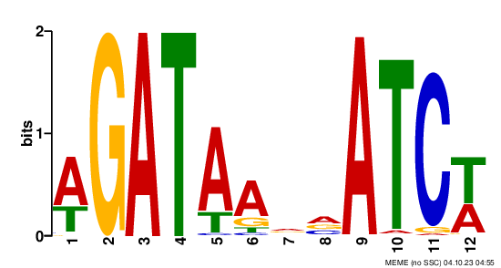

Figure 1: GATA3 motif variants 2

**Input 1** A peak summit file. This file was originally generated with `Macs3` during peak calling step, then processed by removing peaks on contigs and within blacklisted regions, finally we use `slopBed -b 50` to make 50bp window at up/downstream of the summit, respectively.

```bash
wc -l GATA_ChIP_summits.bed
head -5 GATA_ChIP_summits.bed
echo ""
wc -l GATA_ChIP_summits_final.bed
head -5 GATA_ChIP_summits_final.bed
echo ""
wc -l GATA_ChIP_summit_100window.bed
head -5 GATA_ChIP_summit_100window.bed
```

```
##    99289 GATA_ChIP_summits.bed
## chr1 10156   10157   GATA_ChIP_peak_1    11.4759
## chr1 11337   11338   GATA_ChIP_peak_2a   3.78065
## chr1 11669   11670   GATA_ChIP_peak_2b   11.7147
## chr1 14036   14037   GATA_ChIP_peak_3    10.3986
## chr1 28866   28867   GATA_ChIP_peak_4a   4.46672
##
##    96868 GATA_ChIP_summits_final.bed
## chr1 827380  827381  GATA_ChIP_peak_28   9.30478
## chr1 845796  845797  GATA_ChIP_peak_29   541.83
## chr1 869497  869498  GATA_ChIP_peak_30   3.78065
## chr1 916769  916770  GATA_ChIP_peak_31   7.79887
## chr1 917534  917535  GATA_ChIP_peak_32   75.0238
##
##    96868 GATA_ChIP_summit_100window.bed
## chr1 827330  827431  GATA_ChIP_peak_28   9.30478
## chr1 845746  845847  GATA_ChIP_peak_29   541.83
## chr1 869447  869548  GATA_ChIP_peak_30   3.78065
## chr1 916719  916820  GATA_ChIP_peak_31   7.79887
## chr1 917484  917585  GATA_ChIP_peak_32   75.0238
```

**Input 2** motif occurence in peak region.

We have used `MAST` to find this unique motif’s occurrence in ChIP peak. The motif coordinates information are stored in “mast_GATA3_PSWM_in_peaks_round2.bed”.

```bash
wc -l mast_GATA3_PSWM_in_peaks_round2.bed
head -5 mast_GATA3_PSWM_in_peaks_round2.bed
```

```
##    10460 mast_GATA3_PSWM_in_peaks_round2.bed
## chr1 996149  996160  1256.25 2.21e-05    +   1
## chr1 3213875 3213886 1455.15 5.8e-06 -   1
## chr1 5603417 5603428 977.79  8.07e-05    -   1
## chr1 5688630 5688641 1236.36 2.5e-05 +   1
## chr1 5959797 5959808 1276.14 1.96e-05    -   1
```

Now, we can use `intersectBed` to find peak with this unique motif, and make a peak summit file.  
`intersectBed -wa` (refer to https://bedtools.readthedocs.io/en/latest/content/tools/intersect.html) reports original entry in A for each overlap.

```bash
module load bedtools
#cd /home/FCAM/ssun/GATA3_ChIP_PRO_July2023/ChIP_final/de_novo_motif/
dir=/home/FCAM/ssun/GATA3_ChIP_PRO_July2023/ChIP_final/peak_call/
motif_cor=mast_GATA3_PSWM_in_peaks_round2.bed

#peaks with motif2
intersectBed -wa -a ${dir}GATA_ChIP_summit_100window.bed -b ${motif_cor} > with_motif_2_100win.bed
```

This bed file stores peak information of chr, start, end, peak-index, intensity. The peak coordinates have a 100bp window, we will center them to 1bp summit later.

```bash
head with_motif_2_100win.bed
```

```
## chr1 996099  996200  GATA_ChIP_peak_35   38.3686
## chr1 3213828 3213929 GATA_ChIP_peak_87   118.864
## chr1 5603406 5603507 GATA_ChIP_peak_106  2.64066
## chr1 5688597 5688698 GATA_ChIP_peak_109  93.8407
## chr1 5959780 5959881 GATA_ChIP_peak_110  65.9829
## chr1 6302654 6302755 GATA_ChIP_peak_117  17.8086
## chr1 6688445 6688546 GATA_ChIP_peak_127  46.3946
## chr1 6795862 6795963 GATA_ChIP_peak_132  646.195
## chr1 7320242 7320343 GATA_ChIP_peak_146  40.0204
## chr1 7539801 7539902 GATA_ChIP_peak_152  131.001
```

**In the above analysis, we choose an arbitrary 100bp window to query for peaks with GATA-like motif2, this is risky because we might lose information if motif exceeds this window. A better way to decide the summit window is: first use `closestBed` to find peak summit (1bp) to the closest motif; then plot the distribution of closest motif distance to summit; we also want to plot the peak intensity. Based on these analysis, we can choose an appropriate window. (do this later)**

Two Inputs: 1) peak summit file (all the peaks); 2) motif coordinates file.

We want to do this unbiasly and with proper control. Thus :

First, for peak summit file, we want to use the GATA3 ChIP peak as our test peak, and a control peak set that is not enriched with GATA motifs (i.e., a ENCODE DNase-seq peak Union set);  
Next, we want to use all GATA3 motif variants we have.

One thing to consider is that, to make this analysis less bias, we probably want to use motif coordinates that was retrieved from genome by `FIMO`.

### 1.3.3 find the closest 3mer-GAT to peak summit with `closestBed`

In this section, we use `bedtools closestBed` (refer to: https://bedtools.readthedocs.io/en/latest/content/tools/closest.html) to find the closest GAT to each provided peak summit.  
Input:  
`-a` is the sorted peak summit file (centered 1bp);  
`-b` is the sorted, and concatenated GAT coordinates file (both plus and minus);

**Prepare the input file -a: peak summit file (centered 1bp)**

```r
#load files contains ChIP summit info
chip.peak.summit=read.table("with_motif_2_100win.bed", header=FALSE)
head(chip.peak.summit)
```

```
##     V1      V2      V3                 V4        V5
## 1 chr1  996099  996200  GATA_ChIP_peak_35  38.36860
## 2 chr1 3213828 3213929  GATA_ChIP_peak_87 118.86400
## 3 chr1 5603406 5603507 GATA_ChIP_peak_106   2.64066
## 4 chr1 5688597 5688698 GATA_ChIP_peak_109  93.84070
## 5 chr1 5959780 5959881 GATA_ChIP_peak_110  65.98290
## 6 chr1 6302654 6302755 GATA_ChIP_peak_117  17.80860
```

```r
nrow(chip.peak.summit)
```

```
## [1] 10467
```

```r
#get the center of summit (1bp) with bigWig package
library(bigWig)
chip.peak.summit1=center.bed(chip.peak.summit, upstreamWindow = 0, downstreamWindow = 0)
head(chip.peak.summit1)
```

```
##     V1      V2      V3                 V4        V5
## 1 chr1  996149  996150  GATA_ChIP_peak_35  38.36860
## 2 chr1 3213878 3213879  GATA_ChIP_peak_87 118.86400
## 3 chr1 5603456 5603457 GATA_ChIP_peak_106   2.64066
## 4 chr1 5688647 5688648 GATA_ChIP_peak_109  93.84070
## 5 chr1 5959830 5959831 GATA_ChIP_peak_110  65.98290
## 6 chr1 6302704 6302705 GATA_ChIP_peak_117  17.80860
```

```r
nrow(chip.peak.summit1)
```

```
## [1] 10467
```

Subset only chr10 peak summit

```r
chip.peak.summit.chr10.4M=chip.peak.summit1[chip.peak.summit1$V1=="chr10",]

nrow(chip.peak.summit.chr10.4M) #580
```

```
## [1] 580
```

```r
head(chip.peak.summit.chr10.4M)
```

```
##        V1     V2     V3                   V4        V5
## 915 chr10 177506 177507  GATA_ChIP_peak_7471   3.19627
## 916 chr10 297414 297415  GATA_ChIP_peak_7477  39.49270
## 917 chr10 406097 406098  GATA_ChIP_peak_7482 582.80200
## 918 chr10 407831 407832  GATA_ChIP_peak_7483  18.99780
## 919 chr10 547056 547057 GATA_ChIP_peak_7491a 630.24200
## 920 chr10 605697 605698  GATA_ChIP_peak_7494  13.37090
```

**Prepare the input file -b: concatenated GAT coordinates file**

Here I am concatenate the plus.36_GAT.bed and minus.14_GAT.bed together.

```r
#load files contains 3mer coordinates info
#plus
plus.GAT.file=read.table(file = "chr10_4M.3.3.3plus.36_GAT.bed", sep="\t", header=FALSE)
#minus
minus.GAT.file=read.table(file = "chr10_4M.3.3.3minus.14_GAT.bed", sep="\t", header=FALSE)
#concatenate the plus and minus file together
all.GAT.file=rbind(plus.GAT.file, minus.GAT.file)
head(all.GAT.file)
```

```
##      V1    V2    V3 V4 V5 V6  V7
## 1 chr10 10455 10458 36 36  + GAT
## 2 chr10 10549 10552 36 36  + GAT
## 3 chr10 10703 10706 36 36  + GAT
## 4 chr10 10866 10869 36 36  + GAT
## 5 chr10 10907 10910 36 36  + GAT
## 6 chr10 10961 10964 36 36  + GAT
```

```r
tail(all.GAT.file)
```

```
##            V1        V2        V3 V4 V5 V6  V7
## 3154818 chr10 133785874 133785877 14 14  - GAT
## 3154819 chr10 133786595 133786598 14 14  - GAT
## 3154820 chr10 133786822 133786825 14 14  - GAT
## 3154821 chr10 133786838 133786841 14 14  - GAT
## 3154822 chr10 133786864 133786867 14 14  - GAT
## 3154823 chr10 133786928 133786931 14 14  - GAT
```

**bedtools closestBed**  
The below function will sort input bed1 and bed2 first, then run `bedtools closestBed` between bed1 and bed2.

```r
# define function
bedTools.closest <- function(functionstring="/usr/local/bin/closestBed",bed1,bed2,opt.string="") {

  options(scipen =99) # not use scientific notation when writing out

  #write bed formatted data.frames to tempfile
  write.table(bed1,file= 'a.file.bed', quote=F,sep="\t",col.names=F,row.names=F)
  write.table(bed2,file= 'b.file.bed', quote=F,sep="\t",col.names=F,row.names=F)

  # create the command string and call the command using system()
  # the command sort a and b file by coordinates
  command1=paste('sort -k1,1 -k2,2n', 'a.file.bed', '> a.file.sorted.bed')
  cat(command1,"\n") #sort -k1,1 -k2,2n a.file.bed > a.file.sorted.bed
  try(system(command1))
  command2=paste('sort -k1,1 -k2,2n', 'b.file.bed', '> b.file.sorted.bed')
  cat(command2,"\n")
  try(system(command2))

  # the command call closestBed on bed1 and bed2
  command=paste(functionstring, opt.string,"-a",'a.file.sorted.bed',"-b",'b.file.sorted.bed',">",'out.file.bed',sep=" ")
  cat(command,"\n")
  try(system(command))

  res=read.table('out.file.bed',header=F, comment.char='')

  # remove intermediate files
  command3=paste('rm', 'a.file.bed', 'b.file.bed', 'a.file.sorted.bed', 'b.file.sorted.bed', 'out.file.bed')
  cat(command3,"\n")
  try(system(command3))

  colnames(res) = c(colnames(bed1), colnames(bed2), 'dis' )
  return(res)
}
```

Parameter `-d` will report the distance from the closest GAT to the peak summit.  
Parameter `-t last` or `-t first` will only report either the last or the first entry in bed2 file if tied distance occurred.  
Here we choose to use `-t first` to report the first coordinates when tie occurred.

Find the closest GAT to peak summit regardless of GAT strandedness

```r
all.distance=bedTools.closest(bed1 = chip.peak.summit.chr10.4M[,1:3], bed2 = all.GAT.file, opt.string = '-d -t first')
write.table(all.distance,file= 'all.distance.bed', quote=F,sep="\t",col.names=F,row.names=F)
```

In this “all.distance’ data frame, V1 to V3 are peak summit coordinates, V4 to V9 are `closestBed` reported **closest motif** to each peak summit. The last column (V11) is the distance from closest motif to peak summit.

```r
all.distance=read.table('all.distance.bed',header=F, comment.char='')
head(all.distance)
```

```
##      V1     V2     V3    V4     V5     V6 V7 V8 V9 V10 V11
## 1 chr10 177506 177507 chr10 177507 177510 14 14  - GAT   1
## 2 chr10 297414 297415 chr10 297410 297413 36 36  + GAT   2
## 3 chr10 406097 406098 chr10 406103 406106 36 36  + GAT   6
## 4 chr10 407831 407832 chr10 407830 407833 14 14  - GAT   0
## 5 chr10 547056 547057 chr10 547078 547081 36 36  + GAT  22
## 6 chr10 605697 605698 chr10 605701 605704 14 14  - GAT   4
```

**coherence check 1**: the number of the closest minus GAT is comparable to the number of the closest plus GAT.

```r
nrow(all.distance)
```

```
## [1] 580
```

```r
nrow(all.distance[all.distance$V9=="+",])
```

```
## [1] 290
```

```r
nrow(all.distance[all.distance$V9=="-",])
```

```
## [1] 290
```

```r
all.distance.100=bedTools.closest(bed1 = chip.peak.summit.chr10.4M[1:100,1:3], bed2 = all.GAT.file, opt.string = '-d -t first')
nrow(all.distance.100)
nrow(all.distance.100[all.distance.100$V6=="+", ]) #51
nrow(all.distance.100[all.distance.100$V6=="-", ]) #49
```

**coherence check 2**: Since we have use `-t first` to take care of the tie, now we have equal number of unique peak with their closest plus or minus or both GAT.

```r
nrow(chip.peak.summit.chr10.4M) # there are 580 unique peak (contains motif 2)
```

```
## [1] 580
```

```r
nrow(all.distance)
```

```
## [1] 580
```

### 1.3.4 visualize 3mer-GAT distribution relative to the defined “closest GAT” on Genome Browser

Previously, we have made a UCSC genome browser trackhub (http://guertinlab.cam.uchc.edu/test_hub/hub.txt) that has the 3mer coordinates region on ref genome.  
We will also upload custom tracks of 1) peak summit file; and 2) closestBed defined closest GAT coordinates (plus, minus, all).

```r
#1)peak summit
write.table(chip.peak.summit.chr10.4M[,1:3],file= 'chip.peak.summit.chr10.4M.bed', quote=F,sep="\t",col.names=F,row.names=F)

#2)closest 3mer.bed
write.table(plus.distance[, 4:9],file= 'plus.closest.GAT.bed', quote=F,sep="\t",col.names=F,row.names=F)
write.table(minus.distance[, 4:9],file= 'minus.closest.GAT.bed', quote=F,sep="\t",col.names=F,row.names=F)
write.table(all.distance[, 4:9],file= 'all.closest.GAT.bed', quote=F,sep="\t",col.names=F,row.names=F)
```

Add trackline:

```bash
awk 'BEGIN {print "browser position chr10:16,000-17,000"
            print "track type=bed name=\"peak.summit.bed\" description=\"peak.summit_bed\" visibility=full autoScale=on useScore=1 color=0,0,0"
            } {print $0}' chip.peak.summit.chr10.4M.bed > chip.peak.summit.chr10.4M_header.bed

awk 'BEGIN {print "browser position chr10:16,000-17,000"
            print "track type=bed name=\"plus.closest.GAT_bed\" description=\"plus.closest.GAT_bed\" visibility=full autoScale=on useScore=1 color=255,0,0"
            } {print $0}' plus.closest.GAT.bed > plus.closest.GAT_header.bed

awk 'BEGIN {print "browser position chr10:16,000-17,000"
            print "track type=bed name=\"minus.closest.GAT_bed\" description=\"minus.closest.GAT_bed\" visibility=full autoScale=on useScore=1 color=0,0,255"
            } {print $0}' minus.closest.GAT.bed > minus.closest.GAT_header.bed

awk 'BEGIN {print "browser position chr10:16,000-17,000"
            print "track type=bed name=\"all.closest.GAT_bed\" description=\"all.closest.GAT_bed\" visibility=full autoScale=on useScore=1 color=255,128,0"
            } {print $0}' all.closest.GAT.bed > all.closest.GAT_header.bed
```

**How `closestBed` calculates distance?**

For GAT on plus strand or minus strand, how does `closestBed` calculate the distance? Does it calculate differently considering the strandedness? Does it calculate differently considering upstream or downstream motif coordinates to peak summit?

To locate a region to visualize on UCSC Genome Browser where the plus GAT and minus GAT has same closest distance to peak summit, Get peak region where the closest plus GAT and closest minus GAT has the same distance to peak summit defined by `bedtools closestBed`.

```r
plus.distance=bedTools.closest(bed1 = chip.peak.summit.chr10.4M[,1:3], bed2 = plus.GAT.file, opt.string = '-d -t first')
minus.distance=bedTools.closest(bed1 = chip.peak.summit.chr10.4M[,1:3], bed2 = minus.GAT.file, opt.string = '-d -t first')
write.table(plus.distance,file= 'plus.distance.bed', quote=F,sep="\t",col.names=F,row.names=F)
write.table(minus.distance,file= 'minus.distance.bed', quote=F,sep="\t",col.names=F,row.names=F)
```

```r
plus.distance=read.table('plus.distance.bed',header=F, comment.char='')
minus.distance=read.table('minus.distance.bed',header=F, comment.char='')
head(plus.distance)
```

```
##      V1     V2     V3    V4     V5     V6 V7 V8 V9 V10 V11
## 1 chr10 177506 177507 chr10 177500 177503 36 36  + GAT   4
## 2 chr10 297414 297415 chr10 297410 297413 36 36  + GAT   2
## 3 chr10 406097 406098 chr10 406103 406106 36 36  + GAT   6
## 4 chr10 407831 407832 chr10 407823 407826 36 36  + GAT   6
## 5 chr10 547056 547057 chr10 547078 547081 36 36  + GAT  22
## 6 chr10 605697 605698 chr10 605680 605683 36 36  + GAT  15
```

```r
head(minus.distance)
```

```
##      V1     V2     V3    V4     V5     V6 V7 V8 V9 V10 V11
## 1 chr10 177506 177507 chr10 177507 177510 14 14  - GAT   1
## 2 chr10 297414 297415 chr10 297417 297420 14 14  - GAT   3
## 3 chr10 406097 406098 chr10 406110 406113 14 14  - GAT  13
## 4 chr10 407831 407832 chr10 407830 407833 14 14  - GAT   0
## 5 chr10 547056 547057 chr10 547085 547088 14 14  - GAT  29
## 6 chr10 605697 605698 chr10 605701 605704 14 14  - GAT   4
```

```r
head(plus.distance[plus.distance$V11 == minus.distance$V11, c('V1', 'V2', 'V3', "V11")])
```

```
##        V1       V2       V3 V11
## 130 chr10 28800971 28800972   0
## 186 chr10 46544821 46544822   0
## 210 chr10 52916681 52916682  10
## 300 chr10 69358043 69358044   0
## 318 chr10 71850201 71850202   3
## 341 chr10 76598664 76598665  14
```

Use peak summit at chr10:71850201-71850202 as an example, plus GAT and minus GAT has same distance =3 reported by `bedtools closestBed`.

```r
minus.distance[minus.distance$V2==71850201,]
```

```
##        V1       V2       V3    V4       V5       V6 V7 V8 V9 V10 V11
## 318 chr10 71850201 71850202 chr10 71850196 71850199 14 14  - GAT   3
```

```r
plus.distance[plus.distance$V2==71850201,]
```

```
##        V1       V2       V3    V4       V5       V6 V7 V8 V9 V10 V11
## 318 chr10 71850201 71850202 chr10 71850204 71850207 36 36  + GAT   3
```

```r
all.distance[all.distance$V2==71850201,]
```

```
##        V1       V2       V3    V4       V5       V6 V7 V8 V9 V10 V11
## 318 chr10 71850201 71850202 chr10 71850196 71850199 14 14  - GAT   3
```

See UCSC genome browser shots here:

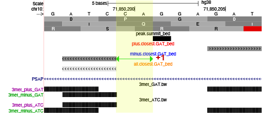

Figure 2: closest upstream GAT to peak summit

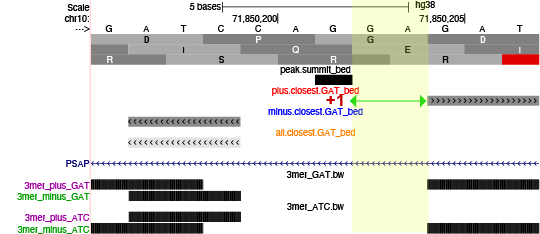

Figure 3: closest downstream GAT to peak summit

In our usage of `closestBed`, we did not consider strandedness, only consider upstream or downstream information during its distance calculation:

## 1.4 step2: making composite profile

In this section, we want to draw composite profile of GAT or ATC distribution relative to the anchored closest GAT.

**We can use the `bigWig` package to query any given 3mer.bigWig file to the anchored GAT position at single base pair resolution, then draw a composite profile to visualize the distribution of the 3mer relative to closest GAT.**

**Input 1)** two .bigWig files that contain the 3mer coordinates info.

```r
library(bigWig)
#GAT on +/- strand
bwPlus_GAT=load.bigWig('testplus.36_GAT.bigWig')
bwMinus_GAT=load.bigWig('testminus.14_GAT.bigWig')

#ATC on +/- strand
bwPlus_ATC=load.bigWig('testplus.14_ATC.bigWig')
bwMinus_ATC=load.bigWig('testminus.36_ATC.bigWig')
```

We can use `query.bigWig` to search the .bigWig file in a genomic window.

```r
query.bigWig(bwPlus_GAT, 'chr10', 1000000, 1000500)
```

```
##        start     end value
## [1,] 1000081 1000084     1
## [2,] 1000168 1000171     1
## [3,] 1000424 1000427     1
```

```r
query.bigWig(bwMinus_GAT, 'chr10', 1000000, 1000500)
```

```
##        start     end value
## [1,] 1000060 1000063     1
## [2,] 1000118 1000121     1
## [3,] 1000301 1000304     1
## [4,] 1000459 1000462     1
```

**Input 2)** a .bed6 file that contains closest GAT (to peak summit) coordinates info.

The bed6 file should define the following columns: “chrom - start - end - name - score - strand”. `bigWig` functions don’t use name and score.

```r
bed6=all.distance[, 4:9] # all.distance -- this is keeping both tied minus/plus GAT
#bed6-plus
bed6_plus=bed6[bed6$V9=="+",]
#bed6-minus
bed6_minus=bed6[bed6$V9=="-",]

nrow(bed6)
```

```
## [1] 580
```

```r
nrow(bed6_plus)
```

```
## [1] 290
```

```r
nrow(bed6_minus)
```

```
## [1] 290
```

### 1.4.1 Anchor GAT -n- GAT (+/-)

In this section, we will set the closest 3mer-GAT as anchor point (bed6), then query the 3mer corordinates .bigWig file.

**Anchor at PLUS closest GAT**  
Take the closest **plus** 3mer-GAT as anchor point and define a new window.

```r
#bigWig input
bwPlus_GAT=load.bigWig('testplus.36_GAT.bigWig')
bwMinus_GAT=load.bigWig('testminus.14_GAT.bigWig')
#bed6 input
bedAnchor=bed6_plus

## define new window
bedAnchorwindow=center.bed(bedAnchor, upstreamWindow = 25, downstreamWindow = 25) #from anchor point, add 25bp downstream and upstream
head(bedAnchor)
```

```
##       V4      V5      V6 V7 V8 V9
## 2  chr10  297410  297413 36 36  +
## 3  chr10  406103  406106 36 36  +
## 5  chr10  547078  547081 36 36  +
## 7  chr10  984358  984361 36 36  +
## 8  chr10 1043079 1043082 36 36  +
## 16 chr10 3887519 3887522 36 36  +
```

```r
head(bedAnchorwindow)
```

```
##       V4      V5      V6 V7 V8 V9
## 2  chr10  297386  297437 36 36  +
## 3  chr10  406079  406130 36 36  +
## 5  chr10  547054  547105 36 36  +
## 7  chr10  984334  984385 36 36  +
## 8  chr10 1043055 1043106 36 36  +
## 16 chr10 3887495 3887546 36 36  +
```

**Query bigWig**  
I choose to use `bed6.step.bpQuery.bigWig` in the bigWig package.  
I choose `bed6.step` not `bed6.region` because we want to define step=1 to count the observations of 3mer at each 1bp position.  
I also choose `bpQuery` not `probeQuery` because: `bpQuery` evaluate each base position of the original bigWig file without consider each genomic interval input. Consider the nature of our input bigWig files (which is 3mer’s coordinates on genome), we want to treat each 3mer separately, and count only once without consider the genomic interval within the 3mer.

`bed6.bpQuery` search for observations in the .bigWig file with region/range provided by each row in .bed6 file.  
`step queries` breaking the region/range up into equal size steps as defined by “step =”.  
we use `step=1` to make single base pair resolution.  
`follow.strand` set to TRUE. This will reverse the direction of - strand output. Since we aim to visualize distribution of the second GAT relative to the anchorred GAT, `follow.strand` set to be TRUE or FALSE doesn’t change the conclusion. But set to be TRUE may be easier for visualizing accumulated GAT.

```r
Anchor.matrix = bed6.step.bpQuery.bigWig(bwPlus_GAT, bwMinus_GAT, bedAnchorwindow,
                 step = 1, as.matrix=TRUE, follow.strand=TRUE)

head(Anchor.matrix)
```

```
##      [,1] [,2] [,3] [,4] [,5] [,6] [,7] [,8] [,9] [,10] [,11] [,12] [,13] [,14]
## [1,]    0    0    0    0    0    0    0    0    1     1     1     0     0     0
## [2,]    0    0    0    0    0    0    0    0    0     0     0     0     0     0
## [3,]    0    0    0    0    0    0    0    0    0     0     0     0     0     0
## [4,]    0    0    0    0    0    0    0    0    0     0     0     0     0     0
## [5,]    0    0    0    0    0    0    0    0    1     1     1     0     0     0
## [6,]    0    0    0    0    0    0    0    0    0     0     0     0     0     0
##      [,15] [,16] [,17] [,18] [,19] [,20] [,21] [,22] [,23] [,24] [,25] [,26]
## [1,]     0     0     0     0     0     0     0     0     0     0     1     1
## [2,]     0     0     0     0     0     0     0     0     0     0     1     1
## [3,]     0     0     0     0     0     0     0     0     0     0     1     1
## [4,]     0     0     0     0     0     0     0     0     0     0     1     1
## [5,]     0     0     0     1     1     1     0     0     0     0     1     1
## [6,]     0     0     0     0     0     0     0     0     0     0     1     1
##      [,27] [,28] [,29] [,30] [,31] [,32] [,33] [,34] [,35] [,36] [,37] [,38]
```

[output cut: 20 more lines]

```r
colnames(Anchor.matrix) = seq(-25, 25, by = 1)
rownames(Anchor.matrix) = bedAnchorwindow[,5]
#filter out rows with no signal
Anchor.matrix=Anchor.matrix[rowSums(Anchor.matrix) != 0,]
head(Anchor.matrix)
```

```
##    -25 -24 -23 -22 -21 -20 -19 -18 -17 -16 -15 -14 -13 -12 -11 -10 -9 -8 -7 -6
## 36   0   0   0   0   0   0   0   0   1   1   1   0   0   0   0   0  0  0  0  0
## 36   0   0   0   0   0   0   0   0   0   0   0   0   0   0   0   0  0  0  0  0
## 36   0   0   0   0   0   0   0   0   0   0   0   0   0   0   0   0  0  0  0  0
## 36   0   0   0   0   0   0   0   0   0   0   0   0   0   0   0   0  0  0  0  0
## 36   0   0   0   0   0   0   0   0   1   1   1   0   0   0   0   0  0  1  1  1
## 36   0   0   0   0   0   0   0   0   0   0   0   0   0   0   0   0  0  0  0  0
##    -5 -4 -3 -2 -1 0 1 2 3 4 5 6 7 8 9 10 11 12 13 14 15 16 17 18 19 20 21 22 23
## 36  0  0  0  0  1 1 1 0 0 0 0 0 0 0 0  0  0  0  0  0  0  0  0  0  0  0  0  0  0
## 36  0  0  0  0  1 1 1 0 0 0 0 0 0 0 0  0  0  0  0  0  0  0  0  0  0  0  0  0  0
## 36  0  0  0  0  1 1 1 0 0 0 0 0 0 0 0  0  0  0  0  0  0  0  0  0  0  0  0  0  0
## 36  0  0  0  0  1 1 1 0 0 0 0 0 0 0 0  0  0  0  0  0  0  0  0  0  0  0  0  0  0
## 36  0  0  0  0  1 1 1 0 0 0 0 0 0 0 0  0  0  0  0  0  0  0  0  0  0  0  0  0  0
## 36  0  0  0  0  1 1 1 0 0 0 0 0 0 0 0  0  0  0  0  0  0  0  0  0  0  0  0  0  0
##    24 25
## 36  0  0
## 36  0  0
## 36  0  0
## 36  0  0
## 36  0  0
## 36  0  0
```

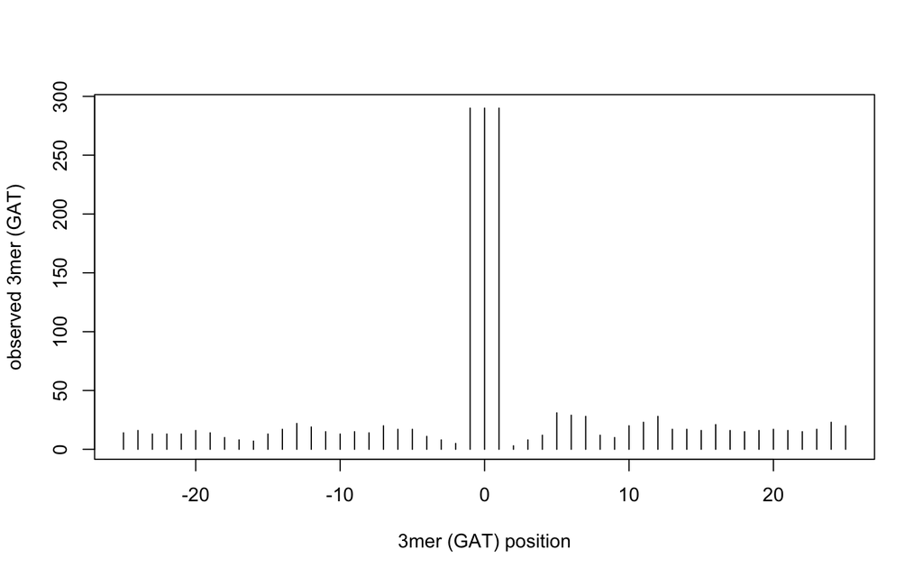

```r
plot(seq(-25, 25, by = 1),colSums(Anchor.matrix),
                  xlab = '3mer (GAT) position',
                  ylab = 'observed 3mer (GAT)', type = "h")
```

In this composite profile, we anchor at the closest **plus GAT**.  
The highest accumulation of observed GAT is at -1, 0, and 1 position. This is because `bed6.step.bpQuery.bigWig` is only querying in **plus GAT.bigWig** file. Thus, each anchored +GAT will find an overlapped +GAT: There are 290 anchored +GAT, so we will see those same 290 plus GAT accumulate at the anchor point.

The smaller accumulation at other position, can tell us in **plus strand**, where are the other GAT relative to the anchor point.

**Anchor at MINUS closest GAT**

Take the closest **minus** 3mer-GAT as anchor point and define the new window.

```r
#bigWig input
bwPlus_GAT=load.bigWig('testplus.36_GAT.bigWig')
bwMinus_GAT=load.bigWig('testminus.14_GAT.bigWig')
#bed6 input
bedAnchor=bed6_minus

## define new window
bedAnchorwindow=center.bed(bedAnchor, upstreamWindow = 25, downstreamWindow = 25) #from anchor point, add 25bp downstream and upstream
head(bedAnchor)
```

```
##       V4      V5      V6 V7 V8 V9
## 1  chr10  177507  177510 14 14  -
## 4  chr10  407830  407833 14 14  -
## 6  chr10  605701  605704 14 14  -
## 9  chr10 1293810 1293813 14 14  -
## 10 chr10 1359443 1359446 14 14  -
## 11 chr10 2619699 2619702 14 14  -
```

```r
head(bedAnchorwindow)
```

```
##       V4      V5      V6 V7 V8 V9
## 1  chr10  177483  177534 14 14  -
## 4  chr10  407806  407857 14 14  -
## 6  chr10  605677  605728 14 14  -
## 9  chr10 1293786 1293837 14 14  -
## 10 chr10 1359419 1359470 14 14  -
## 11 chr10 2619675 2619726 14 14  -
```

Query.bigWig:  
Notice that `follow.strand` is set to be TRUE. This will reverse the direction of - strand output.

```r
Anchor.matrix = bed6.step.bpQuery.bigWig(bwPlus_GAT, bwMinus_GAT, bedAnchorwindow,
                 step = 1, as.matrix=TRUE, follow.strand=TRUE)

head(Anchor.matrix)
```

```
##      [,1] [,2] [,3] [,4] [,5] [,6] [,7] [,8] [,9] [,10] [,11] [,12] [,13] [,14]
## [1,]    0    0    1    1    1    0    0    0    0     0     0     1     1     1
## [2,]    0    0    0    0    0    0    0    0    0     0     0     0     0     0
## [3,]    0    0    0    0    0    0    0    0    0     0     0     0     0     0
## [4,]    0    0    0    0    0    0    0    0    0     0     0     0     0     0
## [5,]    0    0    0    0    0    0    0    0    0     0     0     0     0     0
## [6,]    0    0    0    0    0    0    0    0    0     0     0     0     0     0
##      [,15] [,16] [,17] [,18] [,19] [,20] [,21] [,22] [,23] [,24] [,25] [,26]
## [1,]     0     0     0     0     0     0     0     0     0     0     1     1
## [2,]     0     0     0     0     0     0     0     0     0     0     1     1
## [3,]     0     0     0     0     0     0     0     0     0     0     1     1
## [4,]     0     0     0     0     0     0     0     0     0     0     1     1
## [5,]     0     0     0     0     0     0     0     0     0     0     1     1
## [6,]     0     0     0     0     0     0     0     0     0     0     1     1
##      [,27] [,28] [,29] [,30] [,31] [,32] [,33] [,34] [,35] [,36] [,37] [,38]
```

[output cut: 20 more lines]

```r
colnames(Anchor.matrix) = seq(-25, 25, by = 1)
rownames(Anchor.matrix) = bedAnchorwindow[,5]
#filter out rows with no signal
Anchor.matrix=Anchor.matrix[rowSums(Anchor.matrix) != 0,]
head(Anchor.matrix)
```

```
##    -25 -24 -23 -22 -21 -20 -19 -18 -17 -16 -15 -14 -13 -12 -11 -10 -9 -8 -7 -6
## 14   0   0   1   1   1   0   0   0   0   0   0   1   1   1   0   0  0  0  0  0
## 14   0   0   0   0   0   0   0   0   0   0   0   0   0   0   0   0  0  0  0  0
## 14   0   0   0   0   0   0   0   0   0   0   0   0   0   0   0   0  0  0  0  0
## 14   0   0   0   0   0   0   0   0   0   0   0   0   0   0   0   0  0  0  0  0
## 14   0   0   0   0   0   0   0   0   0   0   0   0   0   0   0   0  0  0  0  0
## 14   0   0   0   0   0   0   0   0   0   0   0   0   0   0   0   0  0  0  0  0
##    -5 -4 -3 -2 -1 0 1 2 3 4 5 6 7 8 9 10 11 12 13 14 15 16 17 18 19 20 21 22 23
## 14  0  0  0  0  1 1 1 0 0 0 0 0 0 0 0  0  1  1  1  0  0  0  0  0  0  0  0  0  0
## 14  0  0  0  0  1 1 1 0 0 0 0 0 0 0 0  0  0  0  0  0  0  0  0  0  0  0  0  0  0
## 14  0  0  0  0  1 1 1 0 0 0 0 0 0 0 0  0  0  0  0  0  0  0  0  0  1  1  1  0  0
## 14  0  0  0  0  1 1 1 0 0 0 0 0 0 0 0  0  0  0  0  0  0  0  0  0  0  0  0  0  0
## 14  0  0  0  0  1 1 1 0 0 0 0 0 0 0 0  0  0  0  0  0  0  0  0  0  0  0  0  0  0
## 14  0  0  0  0  1 1 1 0 0 0 0 0 0 0 0  0  0  0  0  0  0  0  0  0  0  0  0  0  0
##    24 25
## 14  0  0
## 14  0  0
## 14  0  0
## 14  0  0
## 14  0  0
## 14  0  0
```

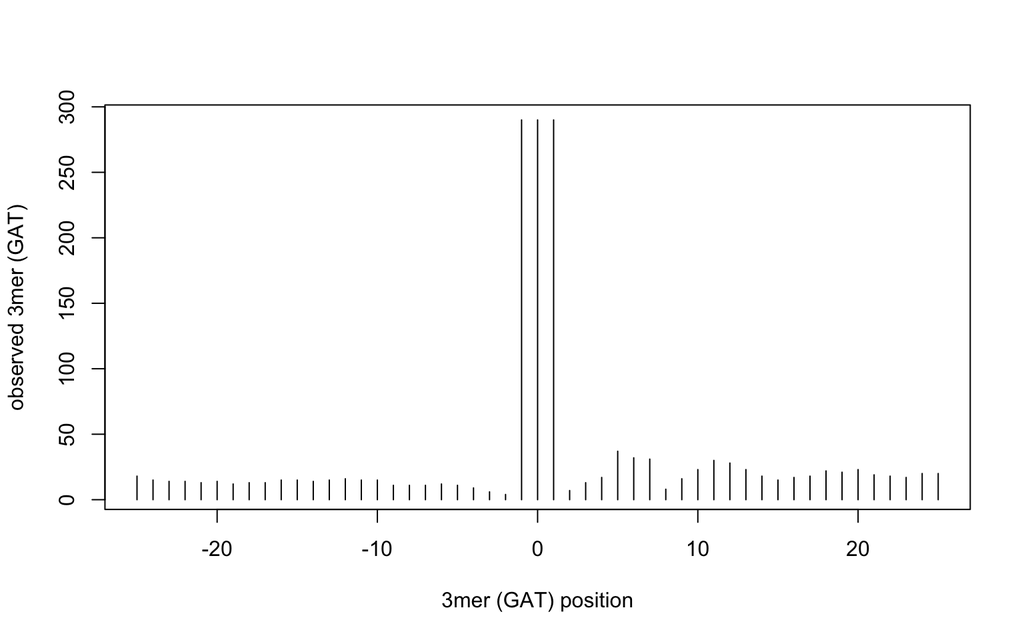

```r
plot(seq(-25, 25, by = 1),colSums(Anchor.matrix),
                  xlab = '3mer (GAT) position',
                  ylab = 'observed 3mer (GAT)', type = "h")
```

In this composite profile, we are seeing similar results.

This time, we anchor at the closest **minus GAT**.  
The highest accumulation of observed GAT is at -1, 0, and 1 position. This is because `bed6.step.bpQuery.bigWig` is only querying in **minus GAT.bigWig** file. Thus, each anchored -GAT will find an overlapped -GAT: There are 290 anchored -GAT, so we will see those same 290 minus GAT accumulate at the anchor point.

The smaller accumulation at other position, can tell us in **minus strand**, where are the other GAT relative to the anchor point.

**Anchor at closest GAT–BOTH MINUS and PLUS**

Take the closest 3mer-GAT (**both plus/minus** ) as anchor point and define the new window.

```r
#bigWig input
bwPlus_GAT=load.bigWig('testplus.36_GAT.bigWig')
bwMinus_GAT=load.bigWig('testminus.14_GAT.bigWig')
#bed6 input
bedAnchor=bed6

## define new window
bedAnchorwindow=center.bed(bedAnchor, upstreamWindow = 25, downstreamWindow = 25) #from anchor point, add 25bp downstream and upstream
head(bedAnchor)
```

```
##      V4     V5     V6 V7 V8 V9
## 1 chr10 177507 177510 14 14  -
## 2 chr10 297410 297413 36 36  +
## 3 chr10 406103 406106 36 36  +
## 4 chr10 407830 407833 14 14  -
## 5 chr10 547078 547081 36 36  +
## 6 chr10 605701 605704 14 14  -
```

```r
head(bedAnchorwindow)
```

```
##      V4     V5     V6 V7 V8 V9
## 1 chr10 177483 177534 14 14  -
## 2 chr10 297386 297437 36 36  +
## 3 chr10 406079 406130 36 36  +
## 4 chr10 407806 407857 14 14  -
## 5 chr10 547054 547105 36 36  +
## 6 chr10 605677 605728 14 14  -
```

Query.bigWig  
`follow.strand` set to TRUE. This will reverse the direction of - strand output.  
coherence check (reverse the input minus and plus bigWig)

```r
Anchor.matrix = bed6.step.bpQuery.bigWig( bwPlus_GAT, bwMinus_GAT, bedAnchorwindow,
                 step = 1, as.matrix=TRUE, follow.strand=TRUE)

head(Anchor.matrix)
```

```
##      [,1] [,2] [,3] [,4] [,5] [,6] [,7] [,8] [,9] [,10] [,11] [,12] [,13] [,14]
## [1,]    0    0    1    1    1    0    0    0    0     0     0     1     1     1
## [2,]    0    0    0    0    0    0    0    0    1     1     1     0     0     0
## [3,]    0    0    0    0    0    0    0    0    0     0     0     0     0     0
## [4,]    0    0    0    0    0    0    0    0    0     0     0     0     0     0
## [5,]    0    0    0    0    0    0    0    0    0     0     0     0     0     0
## [6,]    0    0    0    0    0    0    0    0    0     0     0     0     0     0
##      [,15] [,16] [,17] [,18] [,19] [,20] [,21] [,22] [,23] [,24] [,25] [,26]
## [1,]     0     0     0     0     0     0     0     0     0     0     1     1
## [2,]     0     0     0     0     0     0     0     0     0     0     1     1
## [3,]     0     0     0     0     0     0     0     0     0     0     1     1
## [4,]     0     0     0     0     0     0     0     0     0     0     1     1
## [5,]     0     0     0     0     0     0     0     0     0     0     1     1
## [6,]     0     0     0     0     0     0     0     0     0     0     1     1
##      [,27] [,28] [,29] [,30] [,31] [,32] [,33] [,34] [,35] [,36] [,37] [,38]
```

[output cut: 20 more lines]

```r
colnames(Anchor.matrix) = seq(-25, 25, by = 1)
rownames(Anchor.matrix) = bedAnchorwindow[,5]
#filter out rows with no signal
Anchor.matrix=Anchor.matrix[rowSums(Anchor.matrix) != 0,]
head(Anchor.matrix)
```

```
##    -25 -24 -23 -22 -21 -20 -19 -18 -17 -16 -15 -14 -13 -12 -11 -10 -9 -8 -7 -6
## 14   0   0   1   1   1   0   0   0   0   0   0   1   1   1   0   0  0  0  0  0
## 36   0   0   0   0   0   0   0   0   1   1   1   0   0   0   0   0  0  0  0  0
## 36   0   0   0   0   0   0   0   0   0   0   0   0   0   0   0   0  0  0  0  0
## 14   0   0   0   0   0   0   0   0   0   0   0   0   0   0   0   0  0  0  0  0
## 36   0   0   0   0   0   0   0   0   0   0   0   0   0   0   0   0  0  0  0  0
## 14   0   0   0   0   0   0   0   0   0   0   0   0   0   0   0   0  0  0  0  0
##    -5 -4 -3 -2 -1 0 1 2 3 4 5 6 7 8 9 10 11 12 13 14 15 16 17 18 19 20 21 22 23
## 14  0  0  0  0  1 1 1 0 0 0 0 0 0 0 0  0  1  1  1  0  0  0  0  0  0  0  0  0  0
## 36  0  0  0  0  1 1 1 0 0 0 0 0 0 0 0  0  0  0  0  0  0  0  0  0  0  0  0  0  0
## 36  0  0  0  0  1 1 1 0 0 0 0 0 0 0 0  0  0  0  0  0  0  0  0  0  0  0  0  0  0
## 14  0  0  0  0  1 1 1 0 0 0 0 0 0 0 0  0  0  0  0  0  0  0  0  0  0  0  0  0  0
## 36  0  0  0  0  1 1 1 0 0 0 0 0 0 0 0  0  0  0  0  0  0  0  0  0  0  0  0  0  0
## 14  0  0  0  0  1 1 1 0 0 0 0 0 0 0 0  0  0  0  0  0  0  0  0  0  1  1  1  0  0
##    24 25
## 14  0  0
## 36  0  0
## 36  0  0
## 14  0  0
## 36  0  0
## 14  0  0
```

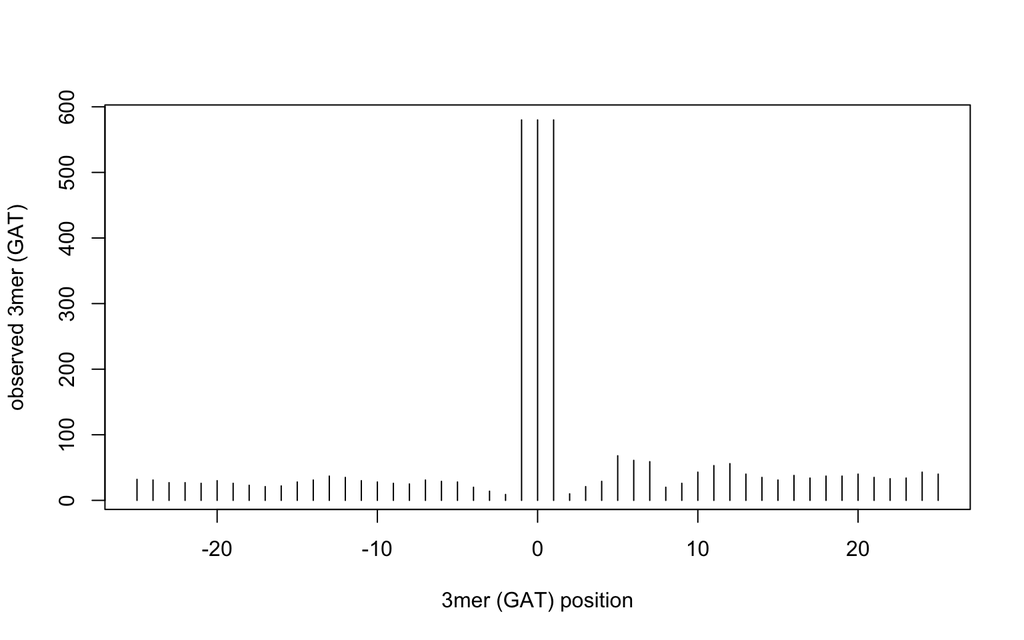

```r
plot(seq(-25, 25, by = 1),colSums(Anchor.matrix),
                  xlab = '3mer (GAT) position',
                  ylab = 'observed 3mer (GAT)', type = "h")
```

This composite profile is simply the previous two composite plot add together (note the y axis, now the highest accumulation counts for observed GAT is 580). Now we are taking consider of both plus and minus strand, to see where other GAT locate relative to the anchored closest GAT.

### 1.4.2 Anchor GAT -n- ATC (+/-)

In this section, we want to draw composite profile of ATC distribution relative to the anchored closest GAT.  
Recall that our peak set are enriched with a GATA3 motif look like this:

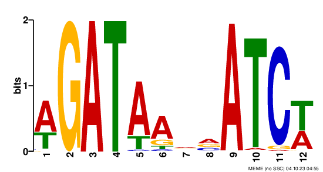

Figure 4: GATA3 motif variants 2

This motif has a specific structure, that is 3mer-GAT followed by 4 fixed spacings, then a 3mer-ATC. Thus, we have some expectation on the composite profile we are going to plot.

**Anchor at closest PLUS GAT**, and query the plus ATC.

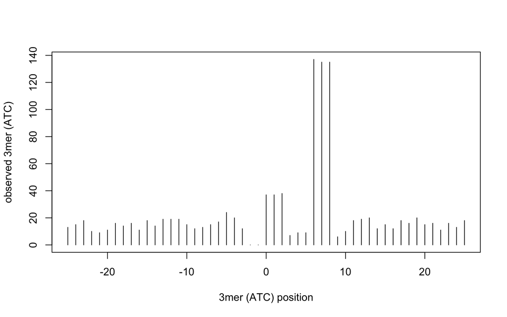

```r
#bwPlus_ATC=load.bigWig('testplus.14_ATC.bw')
#bwMinus_ATC=load.bigWig('testminus.36_ATC.bw')
bedAnchor=bed6_plus

## define new window
bedAnchorwindow=center.bed(bedAnchor, upstreamWindow = 25, downstreamWindow = 25) #from anchor point, add 25bp downstream and upstream
#head(bedAnchor)
#head(bedAnchorwindow)

Anchor.matrix = bed6.step.bpQuery.bigWig(bwPlus_ATC, bwMinus_ATC, bedAnchorwindow,
                 step = 1, as.matrix=TRUE, follow.strand=TRUE)

#head(Anchor.matrix)
colnames(Anchor.matrix) = seq(-25, 25, by = 1)
rownames(Anchor.matrix) = bedAnchorwindow[,5]
#filter out rows with no signal
Anchor.matrix=Anchor.matrix[rowSums(Anchor.matrix) != 0,]
#head(Anchor.matrix)

plot(seq(-25, 25, by = 1),colSums(Anchor.matrix),
                  xlab = '3mer (ATC) position',
                  ylab = 'observed 3mer (ATC)', type = "h")
```

Through plotting the previous three composite profiles of GAT distribution relative to GAT, we know that **the anchored GAT is at -1, 0 and 1 position**.

When we query the 3mer-ATC, notice that:  
If we think A, T, C, G as to have equal chance to be observed at each position, then position 0,1,2 will have 25% chance to find observation of ATC. Because position 0 and 1 is “A” and “T”, there are 25% chance that position 3 being a “C”, in which case we would observe an “ATC”.  
In the other hand, position -1 will have 0% chance to find observation of ATC, because it is a “G”.

Regardless of the situation listed above, in this composite profile, we can clearly see the highest accumulation of observation start at position 6, this is **4 bp away** from the anchor point at position 1. Which is exacylt what we expect based on the known motif structure.

The smaller accumulation at other position, can tell us in **plus strand**, where are the other ATC relative to the anchor point.

**Anchor at closest MINUS GAT**, and query the **minus ATC**.

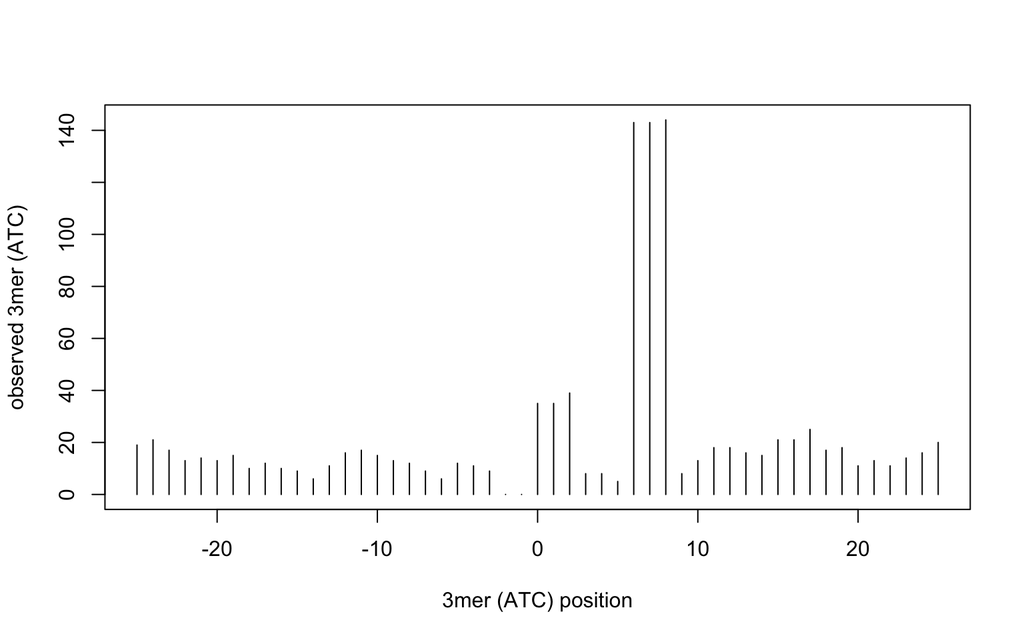

```r
#bwPlus_ATC=load.bigWig('testplus.14_ATC.bw')
#bwMinus_ATC=load.bigWig('testminus.36_ATC.bw')
bedAnchor=bed6_minus

## define new window
bedAnchorwindow=center.bed(bedAnchor, upstreamWindow = 25, downstreamWindow = 25) #from anchor point, add 25bp downstream and upstream
#head(bedAnchor)
#head(bedAnchorwindow)

Anchor.matrix = bed6.step.bpQuery.bigWig(bwPlus_ATC, bwMinus_ATC, bedAnchorwindow,
                 step = 1, as.matrix=TRUE, follow.strand=TRUE)

#head(Anchor.matrix)
colnames(Anchor.matrix) = seq(-25, 25, by = 1)
rownames(Anchor.matrix) = bedAnchorwindow[,5]
#filter out rows with no signal
Anchor.matrix=Anchor.matrix[rowSums(Anchor.matrix) != 0,]
#head(Anchor.matrix)

plot(seq(-25, 25, by = 1),colSums(Anchor.matrix),
                  xlab = '3mer (ATC) position',
                  ylab = 'observed 3mer (ATC)', type = "h")
```

This composte profile is similar as the previous one, this can tell us in **minus strand**, where are the ATC relative to the anchor point.  
Again, as expected, we see the most observation of ATC relative to anchor point is 4bp away.

**Anchor at closest GAT**, and query both **plus/minus ATC**.

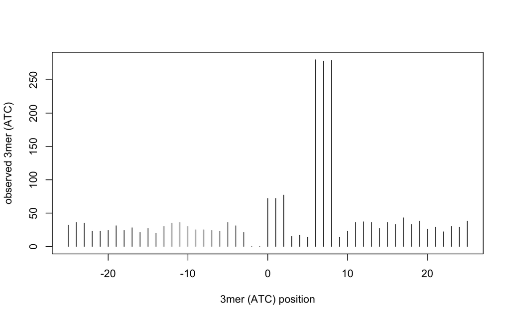

```r
#bwPlus_ATC=load.bigWig('testplus.14_ATC.bw')
#bwMinus_ATC=load.bigWig('testminus.36_ATC.bw')
bedAnchor=bed6

## define new window
bedAnchorwindow=center.bed(bedAnchor, upstreamWindow = 25, downstreamWindow = 25) #from anchor point, add 25bp downstream and upstream
#head(bedAnchor)
#head(bedAnchorwindow)

Anchor.matrix = bed6.step.bpQuery.bigWig(bwPlus_ATC, bwMinus_ATC, bedAnchorwindow,
                 step = 1, as.matrix=TRUE, follow.strand=TRUE)

#head(Anchor.matrix)
colnames(Anchor.matrix) = seq(-25, 25, by = 1)
rownames(Anchor.matrix) = bedAnchorwindow[,5]
#filter out rows with no signal
Anchor.matrix=Anchor.matrix[rowSums(Anchor.matrix) != 0,]
#head(Anchor.matrix)

plot(seq(-25, 25, by = 1),colSums(Anchor.matrix),
                  xlab = '3mer (ATC) position',
                  ylab = 'observed 3mer (ATC)', type = "h")
```

This composte profile is the add up of the previous two profiles. This is plotting all ATC on genome relative to the anchored GAT.  
We see the most ATC accumulated 4bp away from the GAT.

# 2 Dec 1st

## 2.1 Generating 3mer coordinates file on full hg38

**3mer_df**: generating a .txt file where the first column are all 64 3mer, second column are the index, and the third column are the corresponding reversed 3mer’s index (indexrc).

```r
#define function to output the reverse compliment sequence
revcomp <- function(sequence) {
  complement_mapping <- c("A" = "T", "T" = "A", "C" = "G", "G" = "C")
  complemented_sequence <- sapply(strsplit(rev(strsplit(sequence, "")[[1]]), NULL), function(base) complement_mapping[base])
  complemented_sequence <- paste(complemented_sequence, collapse = "")
  return(complemented_sequence)
}

# 64 3mer with index
all.64 = expand.grid(rep(list(c('A','C','G','T')), 3))
all.64.df = data.frame(apply(all.64, 1 , paste, collapse = ""))
all.64.df[,1] = all.64.df[order(all.64.df[,1]),]
all.64.df[,2] = 1:64

# 64 reversed 3mer with indexrc
rev.df = data.frame(as.character(all.64.df[,1]))
rev.df[] = apply(rev.df, 1, revcomp)
rev.df[,2] = 1:64
colnames(rev.df)= c('rc', 'indexrc')


colnames(all.64.df) = c('three_mer', 'index')
all.64.df.rc = merge(all.64.df, rev.df, by.x = 'three_mer', by.y = 'rc')
write.table(all.64.df.rc, file = 'all_64_df.txt', quote=FALSE, row.names =FALSE, col.names = FALSE, sep = '\t')
```

**Ref Genome** Here, I use the full hg38 genome as the input reference genome;

```bash
#cd /home/FCAM/ssun/Genome/
wget https://hgdownload.cse.ucsc.edu/goldenpath/hg38/bigZips/hg38.fa.gz
gunzip hg38.fa.gz
```

**seqOutBias** `seqOutBias seqtable` will generate a seqtable file (.tbl) which is a compressed form that stores the mappability information (if you provide aligned reads info) as well as corresponding parameters (read length, k-mer size, and cut-site offsets).

`seqOutBias dump` can extract info from the seqtable file and output plain txt file in a form of “chrom:start-end”. It will also list the input parameters (read-size, kmer-size, etc.) that were used to build the sequence table file.

use read-size=1000 –kmer-size=3 –plus-offset=3 –minus-offset=3

```r
#! /bin/sh

#SBATCH --job-name=getfull3mer_1000.sh
#SBATCH -N 1
#SBATCH -n 1
#SBATCH -c 32
#SBATCH -p himem
#SBATCH --qos=himem
#SBATCH --mem=128G
#SBATCH --mail-type=ALL
#SBATCH --mail-user=ssun@uchc.edu
#SBATCH -o getfull3mer_1000.sh_%j.out
#SBATCH -e getfull3mer_1000.sh_%j.err

hostname
export PATH=$PATH:/home/FCAM/ssun/packages/://home/FCAM/ssun/scripts
module load genometools/1.5.10
module load ucsc_genome/2012.05.22
module load rust

genome=/home/FCAM/ssun/Genome/hg38.fa

seqOutBias seqtable ${genome} --read-size=1000 --kmer-size=3 --plus-offset=3 --minus-offset=3 --out=hg38.3.3.3.tbl
seqOutBias dump hg38.3.3.3.tbl > hg38.3.3.3.dump.txt
mkdir seqdump
mv hg38.3.3.3.dump.txt seqdump
mv all_64_df.txt seqdump
cd seqdump

while read line; do
 mer=$(echo $line | awk -F" " '{print $1}')
 idx=$(echo $line | awk -F" " '{print $2}')
 rcidx=$(echo $line | awk -F" " '{print $3}')
 echo $mer
 echo $idx
 echo $rcidx
 python /home/FCAM/ssun/scripts/dump_to_kmer.py -i hg38.3.3.3.dump.txt -p $idx -m $rcidx -s $mer
done <all_64_df.txt
```